# 4.14 Demo: Linear Regression

**Summary:**

```
1. Visualize the relationship among the features and the target variable
2. Apply Linear and Muliple Linear Regression
3. Hypothsis Testing
4. Feature Selection
5. Handling Categorical predictors
```

```python
import pandas as pd
import matplotlib.pyplot as plt
from sklearn.metrics import r2_score, mean_squared_error
from math import sqrt

%matplotlib inline
```

```python
data = pd.read_csv('Advertising.csv', index_col=0)
data.columns = ['TV', 'Radio', 'Newspaper', 'Sales']
data.head()
```

|  | TV | Radio | Newspaper | Sales |
| --- | --- | --- | --- | --- |
| 1 | 230.1 | 37.8 | 69.2 | 22.1 |
| 2 | 44.5 | 39.3 | 45.1 | 10.4 |
| 3 | 17.2 | 45.9 | 69.3 | 9.3 |
| 4 | 151.5 | 41.3 | 58.5 | 18.5 |
| 5 | 180.8 | 10.8 | 58.4 | 12.9 |

```python
data.shape
```

```
(200, 4)
```

## Visualize the relationship between the features and target

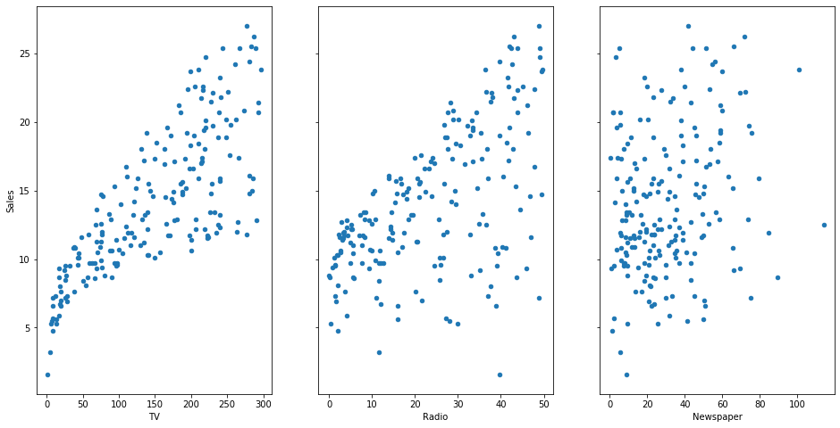

```python
# visualize the relationship between the features and target

fig, axs = plt.subplots(1, 3, sharey=True)
data.plot(kind='scatter', x='TV', y='Sales', ax=axs[0], figsize=(16,8))
data.plot(kind='scatter', x='Radio', y='Sales', ax=axs[1])
data.plot(kind='scatter', x='Newspaper', y='Sales', ax=axs[2])
```

Looking at the output, we do see a relationship between ads and sales.

## Apply Simple Linear Regression

```python
# applying linear regression to estimate the rship between sales and ads spending

feature_cols = ['TV']
x = data[feature_cols]
y = data.Sales
```

```python
from sklearn.linear_model import LinearRegression
lm = LinearRegression()  # initialize the model
lm.fit(x, y)
```

```
LinearRegression()
```

```python
print(lm.intercept_)
print(lm.coef_)
```

```
7.032593549127693
[0.04753664]
```

We can say that a unit increase in TV ad spending is associated with a 0.04753 unit increase in sales.

So let's say that there is a new market where there will be a $50k spend on TV adverts, use the previous results to calculate the sales:

y = mx + c ---Linear equation

```python
7.032594 + 0.047537*50
```

```
9.409444
```

```python
# Let's predict the sales

X_new = pd.DataFrame({'TV':[50]})
X_new.head()
```

|  | TV |
| --- | --- |
| 0 | 50 |

```python
lm.predict(X_new)
```

```
array([9.40942557])
```

That is a prediction of 9,400 sales in that market

```python
# Let's make predictions for the smallest and largest observed values of X and use it to plot the least squares line
X_new = pd.DataFrame({'TV':[data.TV.min(), data.TV.max()]})
X_new.head()
```

|  | TV |
| --- | --- |
| 0 | 0.7 |
| 1 | 296.4 |

```python
preds = lm.predict(X_new)
preds
```

```
array([ 7.0658692 , 21.12245377])
```

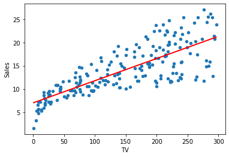

```python
# initialize the scatter plot for TV and sales
data.plot(kind='scatter', x='TV', y='Sales')
plt.plot(X_new, preds, c='red', linewidth=2)
```

We can say that we have a high bias and a low variance model.

### Hypothesis testing and p-value

Using the null hypothesis, let's assume that 'There is no relationship between TV ads and sales'.

Let's test this hypothesis. We shall reject the null hypothesis if the 95% confidence interval does not include o i.e.

Reject null hypothesis if p<0.05 Fail to reject null hypothesis if p>0.05

```python
import statsmodels.formula.api as smf  # import statsmodel
lm = smf.ols(formula='Sales ~ TV', data=data).fit()   # apply ols on tv sales
```

```python
# confidence interval of the fitted parameters
lm.conf_int()
```

|  | 0 | 1 |
| --- | --- | --- |
| Intercept | 6.129719 | 7.935468 |
| TV | 0.042231 | 0.052843 |

```python
# printing the p-value
lm.pvalues
```

```
Intercept    1.406300e-35
TV           1.467390e-42
dtype: float64
```

The output above shows the p values for the model coefficients. The p value represents the possibility that the coefficient is actually 0.

In this case, the p-value for TV is far less than 0.05 hence we infer that **there is a relationship between TV ads and sales**.

### How well does the model fit the data?

The most common way to evaluate the overall fit of a linear model is by using the **r2 value**

Let's print the rsquared value

```python
lm.rsquared
```

```
0.611875050850071
```

It's hard to say if this is a good value. The threshold for a good rsquared value depends on the domain therefore it is useful as a tool for comparing different models

## Apply Multi Linear Regression

```python
feature_cols = ['TV', 'Radio', 'Newspaper']
X = data[feature_cols]
y = data.Sales

from sklearn.linear_model import LinearRegression
from sklearn.model_selection import train_test_split

X_train, X_test, y_train, y_test = train_test_split(X, y, test_size=0.3, random_state=42)
lm = LinearRegression()  # initialize the model

# unsplit data - don't make prediction with this
lm.fit(X, y)
print(lm.intercept_)
print(lm.coef_)
```

```
2.9388893694594085
[ 0.04576465  0.18853002 -0.00103749]
```

```python
# using split data
lm.fit(X_train, y_train)
print(lm.intercept_)
print(lm.coef_)

predictions = lm.predict(X_test)
print(sqrt(mean_squared_error(y_test, predictions)))
```

```
2.708949092515912
[0.04405928 0.1992875  0.00688245]
1.9485372043446383
```

```python
# using the ols regression result, we get a lot of the information in the model summary output
lm = smf.ols(formula='Sales ~ TV + Radio + Newspaper', data=data).fit()  # data is the original dataframe
lm.conf_int()
```

|  | 0 | 1 |
| --- | --- | --- |
| Intercept | 2.323762 | 3.554016 |
| TV | 0.043014 | 0.048516 |
| Radio | 0.171547 | 0.205513 |
| Newspaper | -0.012616 | 0.010541 |

```python
lm.summary()
```

OLS Regression Results

| Dep. Variable: | Sales | R-squared: | 0.897 |
| --- | --- | --- | --- |
| Model: | OLS | Adj. R-squared: | 0.896 |
| Method: | Least Squares | F-statistic: | 570.3 |
| Date: | Sun, 11 Oct 2020 | Prob (F-statistic): | 1.58e-96 |
| Time: | 00:32:23 | Log-Likelihood: | -386.18 |
| No. Observations: | 200 | AIC: | 780.4 |
| Df Residuals: | 196 | BIC: | 793.6 |
| Df Model: | 3 |  |  |
| Covariance Type: | nonrobust |  |  |

|  | coef | std err | t | P>\|t\| | [0.025 | 0.975] |
| --- | --- | --- | --- | --- | --- | --- |
| Intercept | 2.9389 | 0.312 | 9.422 | 0.000 | 2.324 | 3.554 |
| TV | 0.0458 | 0.001 | 32.809 | 0.000 | 0.043 | 0.049 |
| Radio | 0.1885 | 0.009 | 21.893 | 0.000 | 0.172 | 0.206 |
| Newspaper | -0.0010 | 0.006 | -0.177 | 0.860 | -0.013 | 0.011 |

| Omnibus: | 60.414 | Durbin-Watson: | 2.084 |
| --- | --- | --- | --- |
| Prob(Omnibus): | 0.000 | Jarque-Bera (JB): | 151.241 |
| Skew: | -1.327 | Prob(JB): | 1.44e-33 |
| Kurtosis: | 6.332 | Cond. No. | 454. |

Warnings:  
[1] Standard Errors assume that the covariance matrix of the errors is correctly specified.

1. TV and Radio have significant t values whereas newspaper does not.
   - **Thus we reject the null hypothesis for TV and Radio**

```
- __However, we fail to reject the null hypothesis for the variable 'Newspaper'__.
```

1. TV and Radio ads spending are both positively associated with sales where as newspaper ads spending is slightly negatively associated with sales. However, this is irrelevant since we have failed to reject the null hypothesis for the variable 'Newspaper'.
2. This model has a higher rsquared value 0.897 than the previous model with 0.61. This means that this model provides a better fit to the data than the model with only the TV variable

## Feature Selection

How do we know what features need to be included in a linear model?

**Tips**

1. Try out different models and only keep the predictions/features if they have small p-values
2. Check if the rquared value goes up when you add new predictors.

*Note: rsquared will always increase when you add features to the model even if they are unrelated to the response.* So selecting a model with the highest rsquared is not a reliable approach for choosing the best linear model.

```python
lm = smf.ols(formula='Sales ~ TV+Radio', data=data).fit()
lm.rsquared
```

```
0.8971942610828956
```

```python
# adding newspaper ads
lm = smf.ols(formula='Sales ~ TV + Radio + Newspaper', data=data).fit()
lm.rsquared
```

```
0.8972106381789522
```

## Handling categorical predictors with only two categories/classes

What if one of the predictors/features was categorical?

Let's create a new feature called size and randomly assign observations to be small or large.

```python
import numpy as np

np.random.seed(12345)

nums = np.random.rand(len(data))
mask_large = nums > 0.5
# assigning observations as small and large
data['Size'] = 'small'
data.loc[mask_large, 'Size'] = 'large'
data.head()
```

|  | TV | Radio | Newspaper | Sales | Size |
| --- | --- | --- | --- | --- | --- |
| 1 | 230.1 | 37.8 | 69.2 | 22.1 | large |
| 2 | 44.5 | 39.3 | 45.1 | 10.4 | small |
| 3 | 17.2 | 45.9 | 69.3 | 9.3 | small |
| 4 | 151.5 | 41.3 | 58.5 | 18.5 | small |
| 5 | 180.8 | 10.8 | 58.4 | 12.9 | large |

```python
# create a dummy variable that represents the categorical values as binary values

data['islarge'] = data.Size.map({'small':0, 'large':1})
data.head()
```

|  | TV | Radio | Newspaper | Sales | Size | islarge |
| --- | --- | --- | --- | --- | --- | --- |
| 1 | 230.1 | 37.8 | 69.2 | 22.1 | large | 1 |
| 2 | 44.5 | 39.3 | 45.1 | 10.4 | small | 0 |
| 3 | 17.2 | 45.9 | 69.3 | 9.3 | small | 0 |
| 4 | 151.5 | 41.3 | 58.5 | 18.5 | small | 0 |
| 5 | 180.8 | 10.8 | 58.4 | 12.9 | large | 1 |

Let's redo the multilinear regression and include the islarge feature

```python
feature_cols = ['TV', 'Radio', 'Newspaper', 'islarge']
X = data[feature_cols]
y = data.Sales

lm = LinearRegression()
lm.fit(X, y)

list(zip(feature_cols, lm.coef_))  # zip returns an iterator
```

```
[('TV', 0.045719820924362775),
 ('Radio', 0.1887281431342787),
 ('Newspaper', -0.0010976794483516655),
 ('islarge', 0.05742385085482776)]
```

```python
lm.coef_
```

```
array([ 0.04571982,  0.18872814, -0.00109768,  0.05742385])
```

How do we interprete this 'islarge' coefficient? For a given amount of TV, Radio, Newspaper ads spending, being a large market is associated with an average increase in sales of 57.42 widgets as compared to a small market.

Let's create a new feature called 'Area' and randomly assign area values as 'rural', suburban, or 'urban'

```python
np.random.seed(123456)

nums = np.random.rand(len(data))
mask_suburban = (nums > 0.33) & (nums < 0.66)
mask_urban = nums > 0.66
data['Area'] = 'rural'
data.loc[mask_suburban, 'Area'] = 'suburban'
data.loc[mask_urban, 'Area'] = 'urban'
data.head()
```

|  | TV | Radio | Newspaper | Sales | Size | islarge | Area |
| --- | --- | --- | --- | --- | --- | --- | --- |
| 1 | 230.1 | 37.8 | 69.2 | 22.1 | large | 1 | rural |
| 2 | 44.5 | 39.3 | 45.1 | 10.4 | small | 0 | urban |
| 3 | 17.2 | 45.9 | 69.3 | 9.3 | small | 0 | rural |
| 4 | 151.5 | 41.3 | 58.5 | 18.5 | small | 0 | urban |
| 5 | 180.8 | 10.8 | 58.4 | 12.9 | large | 1 | suburban |

Now we create another dummy variable.

Here is how we interprete the codes:

- rural is coded as Area_surburban==0 & Area_urban==0
- surburban is coded as Area_surburban==1 & Area_urban==0
- urban is coded as Area_surburban==0 & Area_urban==1

```python
area_dummies = pd.get_dummies(data.Area, prefix='Area').iloc[:,1:]
data = pd.concat([data, area_dummies], axis=1)
data.head()
```

|  | TV | Radio | Newspaper | Sales | Size | islarge | Area | Area_suburban | Area_urban |
| --- | --- | --- | --- | --- | --- | --- | --- | --- | --- |
| 1 | 230.1 | 37.8 | 69.2 | 22.1 | large | 1 | rural | 0 | 0 |
| 2 | 44.5 | 39.3 | 45.1 | 10.4 | small | 0 | urban | 0 | 1 |
| 3 | 17.2 | 45.9 | 69.3 | 9.3 | small | 0 | rural | 0 | 0 |
| 4 | 151.5 | 41.3 | 58.5 | 18.5 | small | 0 | urban | 0 | 1 |
| 5 | 180.8 | 10.8 | 58.4 | 12.9 | large | 1 | suburban | 1 | 0 |

Let's include the 2 dummy variables in the model

```python
feature_cols = ['TV', 'Radio', 'Newspaper', 'islarge', 'Area_suburban', 'Area_urban']
X = data[feature_cols]
y = data.Sales

lm = LinearRegression()
lm.fit(X, y)

print(feature_cols, lm.coef_)
```

```
['TV', 'Radio', 'Newspaper', 'islarge', 'Area_suburban', 'Area_urban'] [ 0.04574401  0.1878667  -0.0010877   0.07739661 -0.10656299  0.26813802]
```

How do we interprete the coefficients?

Considering all the other variables is fixed, being a suburban area is assocaited with an average decrease in sales of 106.56 widgets as compared to the baseline level which is rural.

Being an urban area is associated with an average increase of 268.13 widgets as compared to rural.